# Data Science - Regressão Linear

# Conhecendo o Dataset

## Importando bibliotecas

```python
import matplotlib.pyplot as plt
%matplotlib inline

import pandas as pd
import numpy as np
```

## O Dataset e o Projeto

### Fonte: https://www.kaggle.com/greenwing1985/housepricing

### Descrição:

Nosso objetivo neste exercício é criar um modelo de machine learning, utilizando a técnica de Regressão Linear, que faça previsões sobre os preços de imóveis a partir de um conjunto de características conhecidas dos imóveis.

Vamos utilizar um dataset disponível no Kaggle que foi gerado por computador para treinamento de machine learning para iniciantes. Este dataset foi modificado para facilitar o nosso objetivo, que é fixar o conhecimento adquirido no treinamento de Regressão Linear.

Siga os passos propostos nos comentários acima de cada célular e bons estudos.

### Dados:

- **precos** - Preços do imóveis
- **area** - Área do imóvel
- **garagem** - Número de vagas de garagem
- **banheiros** - Número de banheiros
- **lareira** - Número de lareiras
- **marmore** - Se o imóvel possui acabamento em mármore branco (1) ou não (0)
- **andares** - Se o imóvel possui mais de um andar (1) ou não (0)

## Leitura dos dados

Dataset está na pasta "Dados" com o nome "HousePrices_HalfMil.csv" em usa como separador ";".

```python
dados = pd.read_csv('dados/HousePrices_HalfMil.csv', sep=';')
```

## Visualizar os dados

```python
dados.head()
```

|  | precos | area | garagem | banheiros | lareira | marmore | andares |
| --- | --- | --- | --- | --- | --- | --- | --- |
| 0 | 51875 | 25 | 3 | 4 | 3 | 0 | 1 |
| 1 | 17875 | 35 | 1 | 3 | 1 | 0 | 0 |
| 2 | 47075 | 195 | 2 | 4 | 2 | 0 | 0 |
| 3 | 38575 | 33 | 2 | 2 | 1 | 0 | 1 |
| 4 | 33775 | 11 | 2 | 3 | 0 | 0 | 1 |

## Verificando o tamanho do dataset

```python
dados.shape
```

```
(1000, 7)
```

# Análises Preliminares

## Estatísticas descritivas

```python
dados.describe().round(2)
```

|  | precos | area | garagem | banheiros | lareira | marmore | andares |
| --- | --- | --- | --- | --- | --- | --- | --- |
| count | 1000.00 | 1000.00 | 1000.00 | 1000.00 | 1000.00 | 1000.00 | 1000.00 |
| mean | 41985.60 | 124.33 | 2.01 | 3.00 | 2.03 | 0.33 | 0.48 |
| std | 12140.39 | 72.39 | 0.81 | 1.43 | 1.42 | 0.47 | 0.50 |
| min | 13150.00 | 1.00 | 1.00 | 1.00 | 0.00 | 0.00 | 0.00 |
| 25% | 33112.50 | 60.75 | 1.00 | 2.00 | 1.00 | 0.00 | 0.00 |
| 50% | 41725.00 | 123.00 | 2.00 | 3.00 | 2.00 | 0.00 | 0.00 |
| 75% | 51175.00 | 187.00 | 3.00 | 4.00 | 3.00 | 1.00 | 1.00 |
| max | 73675.00 | 249.00 | 3.00 | 5.00 | 4.00 | 1.00 | 1.00 |

## Matriz de correlação

O **coeficiente de correlação** é uma medida de associação linear entre duas variáveis e situa-se entre **-1** e **+1** sendo que **-1** indica associação negativa perfeita e **+1** indica associação positiva perfeita.

### Observe as correlações entre as variáveis:

- Quais são mais correlacionadas com a variável dependete (Preço)?
- Qual o relacionamento entre elas (positivo ou negativo)?
- Existe correlação forte entre as variáveis explicativas?

```python
dados.corr().round(4)
```

|  | precos | area | garagem | banheiros | lareira | marmore | andares |
| --- | --- | --- | --- | --- | --- | --- | --- |
| precos | 1.0000 | 0.1177 | 0.1028 | 0.1244 | 0.1072 | 0.4308 | 0.6315 |
| area | 0.1177 | 1.0000 | -0.0075 | -0.0114 | 0.0121 | -0.0153 | -0.0180 |
| garagem | 0.1028 | -0.0075 | 1.0000 | 0.0671 | 0.0605 | -0.0156 | -0.0206 |
| banheiros | 0.1244 | -0.0114 | 0.0671 | 1.0000 | 0.0484 | -0.0253 | -0.0182 |
| lareira | 0.1072 | 0.0121 | 0.0605 | 0.0484 | 1.0000 | 0.0296 | -0.0035 |
| marmore | 0.4308 | -0.0153 | -0.0156 | -0.0253 | 0.0296 | 1.0000 | -0.0065 |
| andares | 0.6315 | -0.0180 | -0.0206 | -0.0182 | -0.0035 | -0.0065 | 1.0000 |

### As variáveis explicativas que apresentam coeficiente de correlação mais alto com a variável dependente preço são o número de andares e se ela possui ou não acabamento em mármore branco

# Comportamento da Variável Dependente (Y)

# Análises gráficas

[figure not shown]

## Importando biblioteca seaborn

```python
import seaborn as sns
```

## Configure o estilo e cor dos gráficos (opcional)

```python
sns.set_palette('pastel')
sns.set_style('darkgrid')
```

## Box plot da variável *dependente* (y)

### Avalie o comportamento da distribuição da variável dependente:

- Parecem existir valores discrepantes (outliers)?
- O box plot apresenta alguma tendência?

https://seaborn.pydata.org/generated/seaborn.boxplot.html?highlight=boxplot#seaborn.boxplot

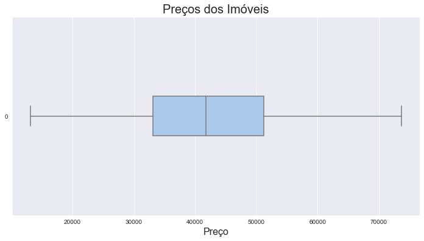

```python
ax = sns.boxplot(data = dados.precos, orient = 'h', width = 0.2)
ax.figure.set_size_inches(12,6)
ax.set_title('Preços dos Imóveis', fontsize = 20)
ax.set_xlabel('Preço', fontsize = 16)
ax
```

### O boxplot não apresenta outliers e nem tendencias.

## Investigando a variável *dependente* (y) juntamente com outras característica

Faça um box plot da variável dependente em conjunto com cada variável explicativa (somente as categóricas).

### Avalie o comportamento da distribuição da variável dependente com cada variável explicativa categórica:

- As estatísticas apresentam mudança significativa entre as categorias?
- O box plot apresenta alguma tendência bem definida?

### Box-plot (Preço X Garagem)

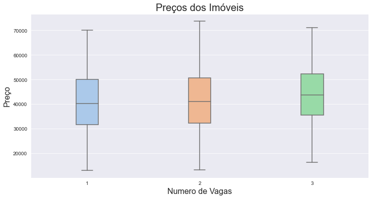

```python
ax = sns.boxplot(x = 'garagem',y = 'precos', data = dados, orient = 'v', width = 0.2)
ax.figure.set_size_inches(12,6)
ax.set_title('Preços dos Imóveis', fontsize = 20)
ax.set_xlabel('Numero de Vagas', fontsize = 16)
ax.set_ylabel('Preço', fontsize = 16)
ax
```

#### OBS: O preço dos imóveis apresenta quase nenhuma variação em relação ao número de vagas na garagem.

### Box-plot (Preço X Banheiros)

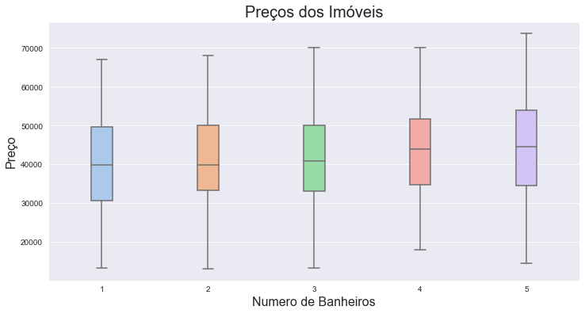

```python
ax = sns.boxplot(x = 'banheiros',y = 'precos', data = dados, orient = 'v', width = 0.2)
ax.figure.set_size_inches(12,6)
ax.set_title('Preços dos Imóveis', fontsize = 20)
ax.set_xlabel('Numero de Banheiros', fontsize = 16)
ax.set_ylabel('Preço', fontsize = 16)
ax
```

### Box-plot (Preço X Lareira)

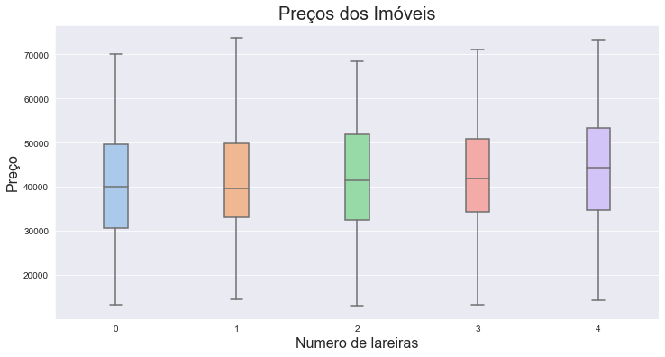

```python
ax = sns.boxplot(x = 'lareira',y = 'precos', data = dados, orient = 'v', width = 0.2)
ax.figure.set_size_inches(12,6)
ax.set_title('Preços dos Imóveis', fontsize = 20)
ax.set_xlabel('Numero de lareiras', fontsize = 16)
ax.set_ylabel('Preço', fontsize = 16)
ax
```

#### OBS: O preço dos imóveis não apresenta variação bem definida em relação ao número de lareiras.

### Box-plot (Preço X Acabamento em Mármore)

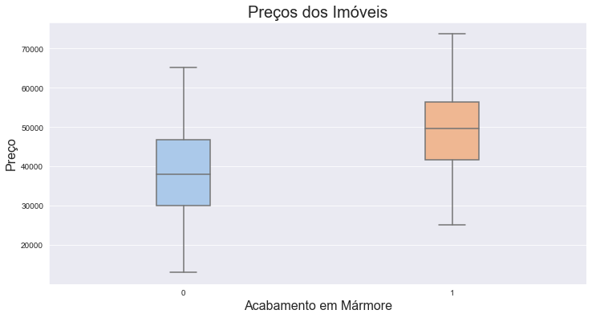

```python
ax = sns.boxplot(x = 'marmore',y = 'precos', data = dados, orient = 'v', width = 0.2)
ax.figure.set_size_inches(12,6)
ax.set_title('Preços dos Imóveis', fontsize = 20)
ax.set_xlabel('Acabamento em Mármore', fontsize = 16)
ax.set_ylabel('Preço', fontsize = 16)
ax
```

#### OBS: O preço dos imóveis apresenta variação bem definida em relação ao acabamento em mármore branco, no caso dos imóveis com acabamento o preço é maior.

### Box-plot (Preço X Andares)

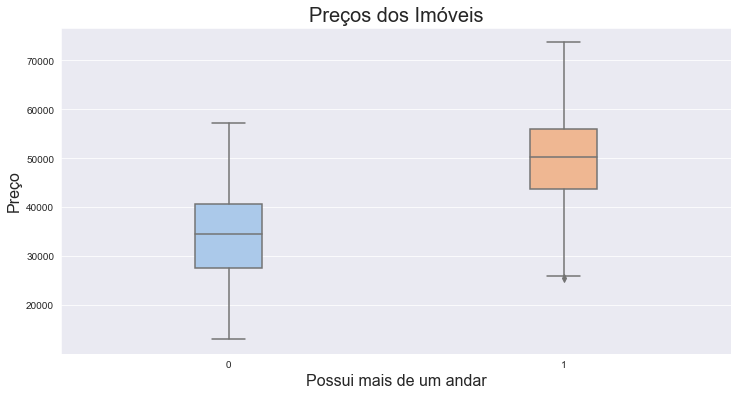

```python
ax = sns.boxplot(x = 'andares',y = 'precos', data = dados, orient = 'v', width = 0.2)
ax.figure.set_size_inches(12,6)
ax.set_title('Preços dos Imóveis', fontsize = 20)
ax.set_xlabel('Possui mais de um andar', fontsize = 16)
ax.set_ylabel('Preço', fontsize = 16)
ax
```

#### OBS: O preço dos imóveis apresenta variação bem definida em relação ao número de andares, quando o imóvel possui mais que 1 andar seu preço é maior.

## Distribuição de frequências da variável *dependente* (y)

Construa um histograma da variável dependente (Preço).

### Avalie:

- A distribuição de frequências da variável dependente parece ser assimétrica?
- É possível supor que a variável dependente segue uma distribuição normal?

https://seaborn.pydata.org/generated/seaborn.distplot.html?highlight=distplot#seaborn.distplot

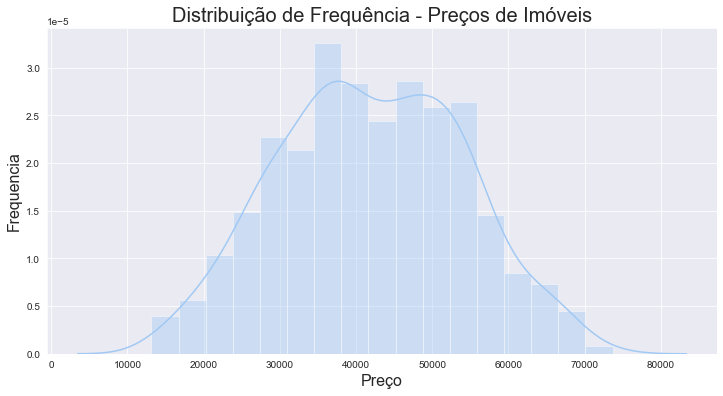

```python
ax = sns.distplot(dados['precos'])
ax.figure.set_size_inches(12,6)
ax.set_title('Distribuição de Frequência - Preços de Imóveis', fontsize = 20)
ax.set_xlabel('Preço', fontsize = 16)
ax.set_ylabel('Frequencia', fontsize = 16)
ax
```

#### OBS: A variável dependente apresenta semelhança com uma distribuição normal, mas apresenta irregularidades, que ficam mais acentuadas ao examinar o histograma com uma granularidade maior.

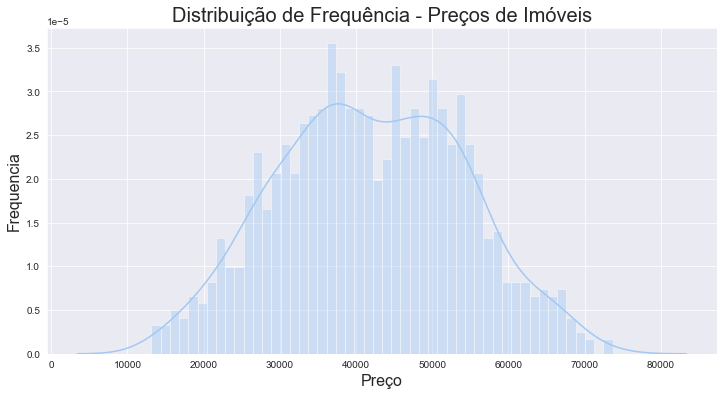

```python
ax = sns.distplot(dados['precos'], bins = 50)
ax.figure.set_size_inches(12,6)
ax.set_title('Distribuição de Frequência - Preços de Imóveis', fontsize = 20)
ax.set_xlabel('Preço', fontsize = 16)
ax.set_ylabel('Frequencia', fontsize = 16)
ax
```

## Gráficos de dispersão entre as variáveis do dataset

## Plotando o pairplot fixando somente uma variável no eixo y

https://seaborn.pydata.org/generated/seaborn.pairplot.html?highlight=pairplot#seaborn.pairplot

Plote gráficos de dispersão da variável dependente contra cada variável explicativa. Utilize o pairplot da biblioteca seaborn para isso.

Plote o mesmo gráfico utilizando o parâmetro kind='reg'.

### Avalie:

- É possível identificar alguma relação linear entre as variáveis?
- A relação é positiva ou negativa?
- Compare com os resultados obtidos na matriz de correlação.

#### OBS: A variável dependente apresenta relação linear positiva com as variáveis explicativas: Área, garagem, banheiros, lareira e marmore. As relações mais acentuadas conforme falado anteriormente são entre as Variáveis Preço e Andares, e Preço e Marmore.

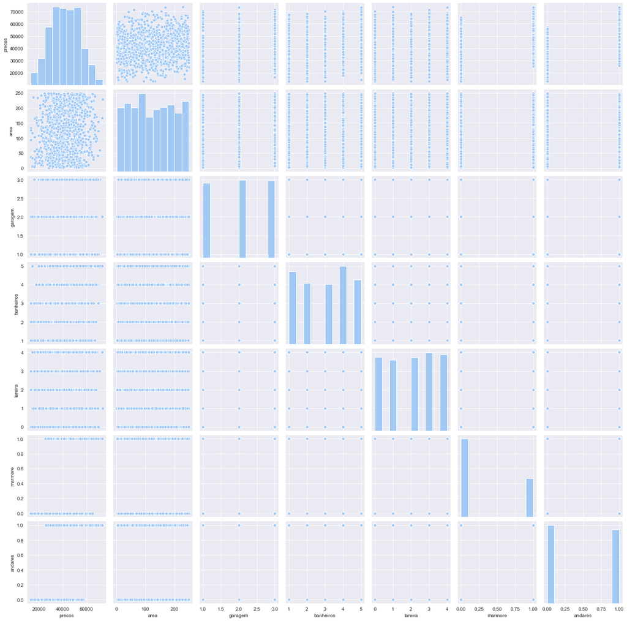

```python
sns.pairplot(dados)
```

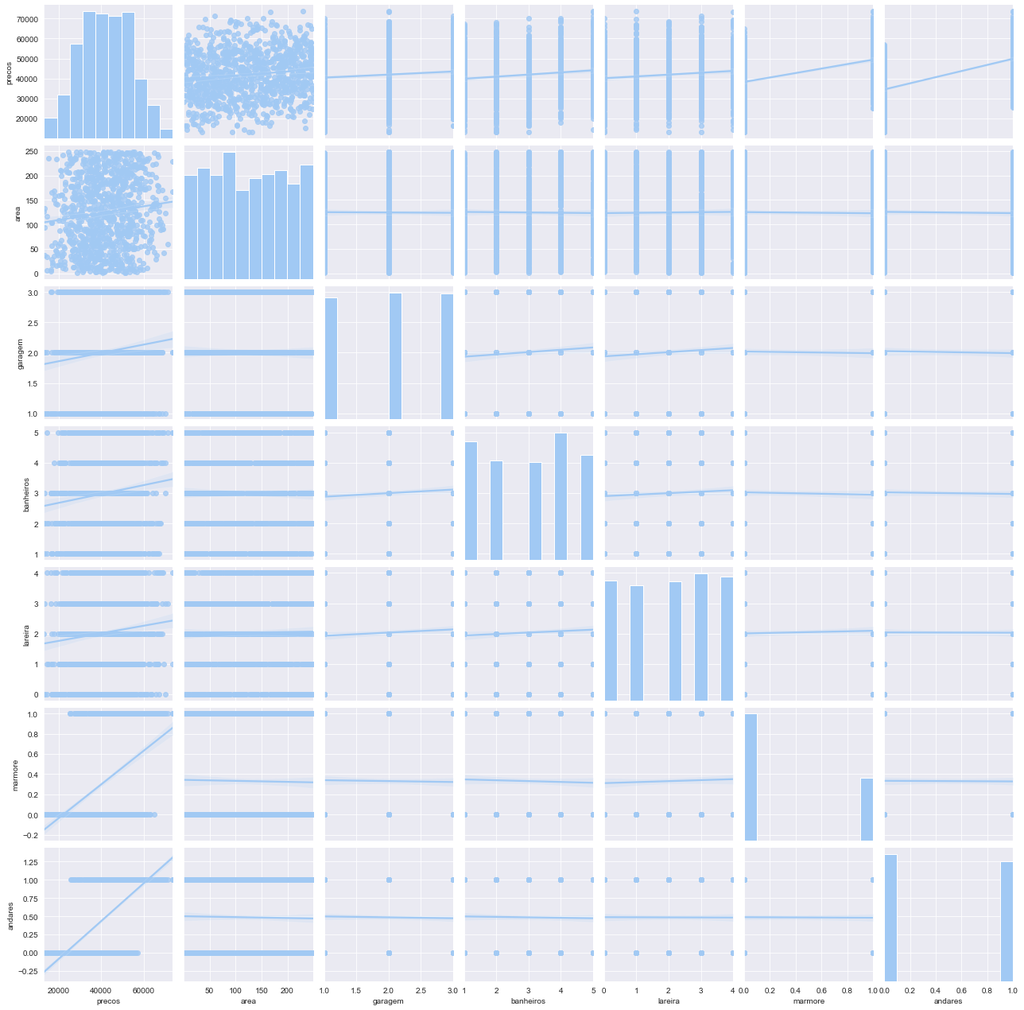

```python
sns.pairplot(dados, kind = 'reg')
```

# Estimando um Modelo de Regressão Linear

## Importando o *train_test_split* da biblioteca *scikit-learn*

https://scikit-learn.org/stable/modules/generated/sklearn.model_selection.train_test_split.html

```python
from sklearn.model_selection import train_test_split
```

## Criando uma Series (pandas) para armazenar a variável dependente (y)

```python
y = dados['precos']
```

## Criando um DataFrame (pandas) para armazenar as variáveis explicativas (X)

```python
dados.head(0)
```

|  | precos | area | garagem | banheiros | lareira | marmore | andares |
| --- | --- | --- | --- | --- | --- | --- | --- |

```python
X = dados[['area', 'garagem', 'banheiros', 'lareira', 'marmore', 'andares']]
```

## Criando os datasets de treino e de teste

```python
X_train, X_test, y_train, y_test = train_test_split(X, y, test_size=0.3)
```

## Importando *LinearRegression* e *metrics* da biblioteca *scikit-learn*

https://scikit-learn.org/stable/modules/generated/sklearn.linear_model.LinearRegression.html

https://scikit-learn.org/stable/modules/classes.html#regression-metrics

```python
from sklearn.linear_model import LinearRegression
from sklearn import metrics
```

## Instanciando a classe *LinearRegression()*

```python
modelo = LinearRegression()
```

## Utilizando o método *fit()* para estimar o modelo linear utilizando os dados de TREINO (y_train e X_train)

https://scikit-learn.org/stable/modules/generated/sklearn.linear_model.LinearRegression.html#sklearn.linear_model.LinearRegression.fit

```python
modelo.fit(X_train, y_train)
```

```
LinearRegression(copy_X=True, fit_intercept=True, n_jobs=None, normalize=False)
```

## Obtendo o coeficiente de determinação (R²) do modelo estimado com os dados de TREINO

https://scikit-learn.org/stable/modules/generated/sklearn.linear_model.LinearRegression.html#sklearn.linear_model.LinearRegression.score

### Avalie:

- O modelo apresenta um bom ajuste?
- Você lembra o que representa o R²?
- Qual medida podemos tomar para melhorar essa estatística?

#### OBS: O ajuste desse modelo está abaixo de 70%. Uma forma de aumentar o coeficiente de determinação é adicionar mais variáveis explicativas que sejam relevantes.

```python
print('R² = {}'.format(modelo.score(X_train, y_train).round(2)))
```

```
R² = 0.64
```

## Gerando previsões para os dados de TESTE (X_test) utilizando o método *predict()*

https://scikit-learn.org/stable/modules/generated/sklearn.linear_model.LinearRegression.html#sklearn.linear_model.LinearRegression.predict

```python
y_previsto = modelo.predict(X_test)
```

## Obtendo o coeficiente de determinação (R²) para as previsões do nosso modelo

https://scikit-learn.org/stable/modules/generated/sklearn.metrics.r2_score.html#sklearn.metrics.r2_score

```python
print('R² = %s' % metrics.r2_score(y_test, y_previsto).round(2))
```

```
R² = 0.67
```

# Obtendo Previsões Pontuais

## Criando um simulador simples

Crie um simulador que gere estimativas de preço a partir de um conjunto de informações de um imóvel.

```python
X.head(1)
```

|  | area | garagem | banheiros | lareira | marmore | andares |
| --- | --- | --- | --- | --- | --- | --- |
| 0 | 25 | 3 | 4 | 3 | 0 | 1 |

```python
area=25
garagem=3
banheiros=4
lareira=3
marmore=0
andares=1
entrada=[[area,garagem,banheiros,lareira, marmore,andares]]

print('$ {0:.2f} '.format(modelo.predict(entrada)[0]))
```

```
$ 47383.18
```

# Métricas de Regressão

## Métricas da regressão

fonte: https://scikit-learn.org/stable/modules/model_evaluation.html#regression-metrics

Algumas estatísticas obtidas do modelo de regressão são muito úteis como critério de comparação entre modelos estimados e de seleção do melhor modelo, as principais métricas de regressão que o scikit-learn disponibiliza para modelos lineares são as seguintes:

### Erro Quadrático Médio

Média dos quadrados dos erros. Ajustes melhores apresentam $EQM$ mais baixo.

$$EQM(y, \hat{y}) = \frac 1n\sum_{i=0}^{n-1}(y_i-\hat{y}_i)^2$$

### Raíz do Erro Quadrático Médio

Raíz quadrada da média dos quadrados dos erros. Ajustes melhores apresentam $\sqrt{EQM}$ mais baixo.

$$\sqrt{EQM(y, \hat{y})} = \sqrt{\frac 1n\sum_{i=0}^{n-1}(y_i-\hat{y}_i)^2}$$

### Coeficiente de Determinação - R²

O coeficiente de determinação (R²) é uma medida resumida que diz quanto a linha de regressão ajusta-se aos dados. É um valor entra 0 e 1.

$$R^2(y, \hat{y}) = 1 - \frac {\sum_{i=0}^{n-1}(y_i-\hat{y}_i)^2}{\sum_{i=0}^{n-1}(y_i-\bar{y}_i)^2}$$

## Obtendo métricas para o modelo

```python
EQM = metrics.mean_squared_error(y_test, y_previsto).round(2)
REQM = np.sqrt(EQM).round(2)
R2= metrics.r2_score(y_test, y_previsto).round(2)

pd.DataFrame([EQM, REQM, R2], ['EQM', 'REQM', 'R²'], columns = ['Métricas'] )
```

[output not shown]

# Salvando e Carregando o Modelo Estimado

## Importando a biblioteca pickle

```python
import pickle
```

## Salvando o modelo estimado

```python
output = open('modelo_precos_imoveis', 'wb')
pickle.dump(modelo, output)
output.close()
```

### Em um novo notebook/projeto Python

#### In [1]:

```
import pickle

modelo = open('modelo_precos_imoveis','rb')
lm_new = pickle.load(modelo)
modelo.close()

area = 38
garagem = 2
banheiros = 4
lareira = 4
marmore = 0
andares = 1

entrada = [[area, garagem, banheiros, lareira, marmore, andares]]

print('$ {0:.2f}'.format(lm_new.predict(entrada)[0]))
```

#### Out [1]:

```
$ 46389.80
```

# Gerando outro modelo sem a variável área

```python
y = dados['precos']
```

```python
dados.columns
```

```
Index(['precos', 'area', 'garagem', 'banheiros', 'lareira', 'marmore',
       'andares'],
      dtype='object')
```

```python
X2 = dados[['garagem', 'banheiros', 'lareira', 'marmore','andares']]
X2.head()
```

|  | garagem | banheiros | lareira | marmore | andares |
| --- | --- | --- | --- | --- | --- |
| 0 | 3 | 4 | 3 | 0 | 1 |
| 1 | 1 | 3 | 1 | 0 | 0 |
| 2 | 2 | 4 | 2 | 0 | 0 |
| 3 | 2 | 2 | 1 | 0 | 1 |
| 4 | 2 | 3 | 0 | 0 | 1 |

```python
X2_train, X2_test, y2_train, y2_test = train_test_split(X2, y, test_size = 0.3)
```

```python
modelo_2 = LinearRegression()
```

```python
modelo_2.fit(X2_train, y2_train)
```

```
LinearRegression(copy_X=True, fit_intercept=True, n_jobs=None, normalize=False)
```

```python
print('Modelo sem a variável área')
print('R² = {}'.format(modelo_2.score(X2_train, y2_train).round(2)))
```

```
Modelo sem a variável área
R² = 0.61
```

```python
y_previsto_2 = modelo_2.predict(X2_test)
EQM = metrics.mean_squared_error(y2_test, y_previsto_2).round(2)
REQM = np.sqrt(EQM).round(2)
R2= metrics.r2_score(y2_test, y_previsto_2).round(2)

pd.DataFrame([EQM, REQM, R2], ['EQM', 'REQM', 'R²'], columns = ['Métricas'] )
```

|  | Métricas |
| --- | --- |
| EQM | 51192662.61 |
| REQM | 7154.90 |
| R² | 0.66 |

```python
EQM = metrics.mean_squared_error(y_test, y_previsto).round(2)
REQM = np.sqrt(EQM).round(2)
R2= metrics.r2_score(y_test, y_previsto).round(2)

pd.DataFrame([EQM, REQM, R2], ['EQM', 'REQM', 'R²'], columns = ['Métricas'] )
```

|  | Métricas |
| --- | --- |
| EQM | 50109714.98 |
| REQM | 7078.82 |
| R² | 0.67 |

```python
## Realmente quando adicionamos mais variáveis o coeficiente de determinação tende a subir
```